# Transforming data with dplyr

This semi-guided tutorial uses functions from the [dplyr](https://dplyr.tidyverse.org) package to transform data in R. You’ll learn how to rename columns, subset rows and generate summary statistics.

We’ll practice using the penguins dataset from the palmerpenguins package which contains body measurements for three different penguin species based in the Palmer Archipelago in Antarctica. The data are available by CC-0 license in accordance with the [Palmer Station LTER Data Policy](http://pal.lternet.edu/data/policies) and the [LTER Data Access Policy for Type I data](https://lternet.edu/data-access-policy).

Source: RStudio / Allison Horst

First let’s install the necessary R packages, [dplyr](https://dplyr.tidyverse.org) and palmerpenguins. You will only need to install the packages once.

```r
install.packages(c("dplyr", "palmerpenguins"), dependencies = TRUE, type = "win.binary")
```

Next we load the packages so that the functions in `dplyr` and the data in `palmerpenguins` are available in the session.

```r
library(dplyr) ; library(palmerpenguins)
```

Run `penguins` to print the data into the console.

```r
penguins
```

```
## # A tibble: 344 × 8
##    species island    bill_length_mm bill_depth_mm flipper_length_mm body_mass_g
##    <fct>   <fct>              <dbl>         <dbl>             <int>       <int>
##  1 Adelie  Torgersen           39.1          18.7               181        3750
##  2 Adelie  Torgersen           39.5          17.4               186        3800
##  3 Adelie  Torgersen           40.3          18                 195        3250
##  4 Adelie  Torgersen           NA            NA                  NA          NA
##  5 Adelie  Torgersen           36.7          19.3               193        3450
##  6 Adelie  Torgersen           39.3          20.6               190        3650
##  7 Adelie  Torgersen           38.9          17.8               181        3625
##  8 Adelie  Torgersen           39.2          19.6               195        4675
##  9 Adelie  Torgersen           34.1          18.1               193        3475
## 10 Adelie  Torgersen           42            20.2               190        4250
## # … with 334 more rows, and 2 more variables: sex <fct>, year <int>
```

Now, let’s have a look at the structure of the penguins data using the function `glimpse()`.

```r
glimpse(penguins)
```

```
## Rows: 344
## Columns: 8
## $ species           <fct> Adelie, Adelie, Adelie, Adelie, Adelie, Adelie, Adel…
## $ island            <fct> Torgersen, Torgersen, Torgersen, Torgersen, Torgerse…
## $ bill_length_mm    <dbl> 39.1, 39.5, 40.3, NA, 36.7, 39.3, 38.9, 39.2, 34.1, …
## $ bill_depth_mm     <dbl> 18.7, 17.4, 18.0, NA, 19.3, 20.6, 17.8, 19.6, 18.1, …
## $ flipper_length_mm <int> 181, 186, 195, NA, 193, 190, 181, 195, 193, 190, 186…
## $ body_mass_g       <int> 3750, 3800, 3250, NA, 3450, 3650, 3625, 4675, 3475, …
## $ sex               <fct> male, female, female, NA, female, male, female, male…
## $ year              <int> 2007, 2007, 2007, 2007, 2007, 2007, 2007, 2007, 2007…
```

The data are in a [tidy](http://vita.had.co.nz/papers/tidy-data.pdf) format so variables are in columns and observations are in rows. There are 8 variables and 344 observations with some missing values recorded as NA. To learn more about the variables you can run `?penguins` in the console.

There are several functions or ‘verbs’ for manipulating data in the `dplyr` package. The functions `select()`, `rename()`, `mutate()`, and `relocate()` can be applied to columns, `filter()`, `slice()`, and `arrange()` to rows, and `summarise()` to groups of rows.

To link each step of the data manipulation process we use the pipe operator. If you are using R 4.1.0. or greater you can use the base R pipe `|>` otherwise we stick with what’s called the [magrittr](https://magrittr.tidyverse.org/reference/pipe.html) pipe: `%>%`. In either case, the pipe is read as ‘then’. So following the example code below, we supply the penguins dataset then count the number of distinct species and then store the relative proportions in a new variable.

```r
penguins %>%
  count(species) %>%
  mutate(prop = n / sum(n))
```

```
## # A tibble: 3 × 3
##   species       n  prop
##   <fct>     <int> <dbl>
## 1 Adelie      152 0.442
## 2 Chinstrap    68 0.198
## 3 Gentoo      124 0.360
```

Now, let’s look at each of the dplyr functions used for transforming data in turn.

### `select()`

*Pick and exclude variables in a dataframe*

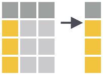

#### by name

Select the variables `species`, `island`, `sex`, and `body_mass_g` by separating them by commas.

```r
penguins %>%
  select(species, island, sex, body_mass_g)
```

```
## # A tibble: 344 × 4
##    species island    sex    body_mass_g
##    <fct>   <fct>     <fct>        <int>
##  1 Adelie  Torgersen male          3750
##  2 Adelie  Torgersen female        3800
##  3 Adelie  Torgersen female        3250
##  4 Adelie  Torgersen <NA>            NA
##  5 Adelie  Torgersen female        3450
##  6 Adelie  Torgersen male          3650
##  7 Adelie  Torgersen female        3625
##  8 Adelie  Torgersen male          4675
##  9 Adelie  Torgersen <NA>          3475
## 10 Adelie  Torgersen <NA>          4250
## # … with 334 more rows
```

#### by exclusion

Select all the variables except `species` by prefixing an exclamation mark.

```r
penguins %>%
  select(!species)
```

```
## # A tibble: 344 × 7
##    island  bill_length_mm bill_depth_mm flipper_length_… body_mass_g sex    year
##    <fct>            <dbl>         <dbl>            <int>       <int> <fct> <int>
##  1 Torger…           39.1          18.7              181        3750 male   2007
##  2 Torger…           39.5          17.4              186        3800 fema…  2007
##  3 Torger…           40.3          18                195        3250 fema…  2007
##  4 Torger…           NA            NA                 NA          NA <NA>   2007
##  5 Torger…           36.7          19.3              193        3450 fema…  2007
##  6 Torger…           39.3          20.6              190        3650 male   2007
##  7 Torger…           38.9          17.8              181        3625 fema…  2007
##  8 Torger…           39.2          19.6              195        4675 male   2007
##  9 Torger…           34.1          18.1              193        3475 <NA>   2007
## 10 Torger…           42            20.2              190        4250 <NA>   2007
## # … with 334 more rows
```

#### a consecutive range

Select the first three variables using a colon to separate the first and last variables.

```r
penguins %>%
  select(1:3)
```

```
## # A tibble: 344 × 3
##    species island    bill_length_mm
##    <fct>   <fct>              <dbl>
##  1 Adelie  Torgersen           39.1
##  2 Adelie  Torgersen           39.5
##  3 Adelie  Torgersen           40.3
##  4 Adelie  Torgersen           NA
##  5 Adelie  Torgersen           36.7
##  6 Adelie  Torgersen           39.3
##  7 Adelie  Torgersen           38.9
##  8 Adelie  Torgersen           39.2
##  9 Adelie  Torgersen           34.1
## 10 Adelie  Torgersen           42
## # … with 334 more rows
```

#### begins with

Select variables that match names that begin with “bill”. `starts_with()` is one of a number of useful helper functions that can be used with `select()` including `ends_with()` and `contains()`.

```r
penguins %>%
  select(starts_with("bill"))
```

```
## # A tibble: 344 × 2
##    bill_length_mm bill_depth_mm
##             <dbl>         <dbl>
##  1           39.1          18.7
##  2           39.5          17.4
##  3           40.3          18
##  4           NA            NA
##  5           36.7          19.3
##  6           39.3          20.6
##  7           38.9          17.8
##  8           39.2          19.6
##  9           34.1          18.1
## 10           42            20.2
## # … with 334 more rows
```

#### by numeric

Select all variables that have numeric values.

```r
penguins %>%
  select(where(is.numeric))
```

```
## # A tibble: 344 × 5
##    bill_length_mm bill_depth_mm flipper_length_mm body_mass_g  year
##             <dbl>         <dbl>             <int>       <int> <int>
##  1           39.1          18.7               181        3750  2007
##  2           39.5          17.4               186        3800  2007
##  3           40.3          18                 195        3250  2007
##  4           NA            NA                  NA          NA  2007
##  5           36.7          19.3               193        3450  2007
##  6           39.3          20.6               190        3650  2007
##  7           38.9          17.8               181        3625  2007
##  8           39.2          19.6               195        4675  2007
##  9           34.1          18.1               193        3475  2007
## 10           42            20.2               190        4250  2007
## # … with 334 more rows
```

#### reorder

Change the order of the variables in a dataframe Here we pick the variables we want in the order we want them and then use the helper function `everything()` to add in the remaining variables.

```r
penguins %>%
  select(year, island, species, sex, everything())
```

```
## # A tibble: 344 × 8
##     year island    species sex    bill_length_mm bill_depth_mm flipper_length_mm
##    <int> <fct>     <fct>   <fct>           <dbl>         <dbl>             <int>
##  1  2007 Torgersen Adelie  male             39.1          18.7               181
##  2  2007 Torgersen Adelie  female           39.5          17.4               186
##  3  2007 Torgersen Adelie  female           40.3          18                 195
##  4  2007 Torgersen Adelie  <NA>             NA            NA                  NA
##  5  2007 Torgersen Adelie  female           36.7          19.3               193
##  6  2007 Torgersen Adelie  male             39.3          20.6               190
##  7  2007 Torgersen Adelie  female           38.9          17.8               181
##  8  2007 Torgersen Adelie  male             39.2          19.6               195
##  9  2007 Torgersen Adelie  <NA>             34.1          18.1               193
## 10  2007 Torgersen Adelie  <NA>             42            20.2               190
## # … with 334 more rows, and 1 more variable: body_mass_g <int>
```

### `rename()`

*Change column names*

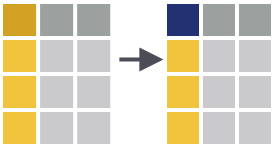

The new variable name is on the left of =.

```r
penguins %>%
  rename(culmen_length_mm = bill_length_mm,
         culmen_depth_mm = bill_depth_mm)
```

```
## # A tibble: 344 × 8
##    species island  culmen_length_mm culmen_depth_mm flipper_length_… body_mass_g
##    <fct>   <fct>              <dbl>           <dbl>            <int>       <int>
##  1 Adelie  Torger…             39.1            18.7              181        3750
##  2 Adelie  Torger…             39.5            17.4              186        3800
##  3 Adelie  Torger…             40.3            18                195        3250
##  4 Adelie  Torger…             NA              NA                 NA          NA
##  5 Adelie  Torger…             36.7            19.3              193        3450
##  6 Adelie  Torger…             39.3            20.6              190        3650
##  7 Adelie  Torger…             38.9            17.8              181        3625
##  8 Adelie  Torger…             39.2            19.6              195        4675
##  9 Adelie  Torger…             34.1            18.1              193        3475
## 10 Adelie  Torger…             42              20.2              190        4250
## # … with 334 more rows, and 2 more variables: sex <fct>, year <int>
```

### `mutate()`

*Add a new variable*

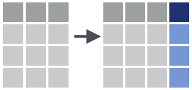

#### calculate

Divide penguin bill length by bill depth and store the results in a new variable called `bill_ratio`.

```r
penguins %>%
  mutate(bill_ratio = bill_length_mm / bill_depth_mm)
```

```
## # A tibble: 344 × 9
##    species island    bill_length_mm bill_depth_mm flipper_length_mm body_mass_g
##    <fct>   <fct>              <dbl>         <dbl>             <int>       <int>
##  1 Adelie  Torgersen           39.1          18.7               181        3750
##  2 Adelie  Torgersen           39.5          17.4               186        3800
##  3 Adelie  Torgersen           40.3          18                 195        3250
##  4 Adelie  Torgersen           NA            NA                  NA          NA
##  5 Adelie  Torgersen           36.7          19.3               193        3450
##  6 Adelie  Torgersen           39.3          20.6               190        3650
##  7 Adelie  Torgersen           38.9          17.8               181        3625
##  8 Adelie  Torgersen           39.2          19.6               195        4675
##  9 Adelie  Torgersen           34.1          18.1               193        3475
## 10 Adelie  Torgersen           42            20.2               190        4250
## # … with 334 more rows, and 3 more variables: sex <fct>, year <int>,
## #   bill_ratio <dbl>
```

#### recode

Create a new variable containing values dependent on multiple if else condition(s) using the `case_when()` helper function.

```r
penguins %>%
  mutate(category = case_when(
    body_mass_g <= 3000 ~ "small",
    body_mass_g > 3000 & body_mass_g <= 4500 ~ "medium",
    body_mass_g > 4500 ~ "large")
    )
```

```
## # A tibble: 344 × 9
##    species island    bill_length_mm bill_depth_mm flipper_length_mm body_mass_g
##    <fct>   <fct>              <dbl>         <dbl>             <int>       <int>
##  1 Adelie  Torgersen           39.1          18.7               181        3750
##  2 Adelie  Torgersen           39.5          17.4               186        3800
##  3 Adelie  Torgersen           40.3          18                 195        3250
##  4 Adelie  Torgersen           NA            NA                  NA          NA
##  5 Adelie  Torgersen           36.7          19.3               193        3450
##  6 Adelie  Torgersen           39.3          20.6               190        3650
##  7 Adelie  Torgersen           38.9          17.8               181        3625
##  8 Adelie  Torgersen           39.2          19.6               195        4675
##  9 Adelie  Torgersen           34.1          18.1               193        3475
## 10 Adelie  Torgersen           42            20.2               190        4250
## # … with 334 more rows, and 3 more variables: sex <fct>, year <int>,
## #   category <chr>
```

#### relevel

Change the order of factor levels of `island` using the [forcats](https://forcats.tidyverse.org/) package function `fct_relevel`.

```r
penguins %>%
  mutate(island = forcats::fct_relevel(island, "Torgersen", "Biscoe", "Dream"))
```

[output not shown]

### `relocate()`

*Move variable(s) before or after another*

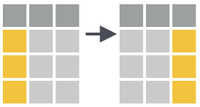

#### to beginning

Make the variable `year` the 1st variable in the dataframe.

```r
penguins %>%
  relocate(year)
```

```
## # A tibble: 344 × 8
##     year species island    bill_length_mm bill_depth_mm flipper_length_mm
##    <int> <fct>   <fct>              <dbl>         <dbl>             <int>
##  1  2007 Adelie  Torgersen           39.1          18.7               181
##  2  2007 Adelie  Torgersen           39.5          17.4               186
##  3  2007 Adelie  Torgersen           40.3          18                 195
##  4  2007 Adelie  Torgersen           NA            NA                  NA
##  5  2007 Adelie  Torgersen           36.7          19.3               193
##  6  2007 Adelie  Torgersen           39.3          20.6               190
##  7  2007 Adelie  Torgersen           38.9          17.8               181
##  8  2007 Adelie  Torgersen           39.2          19.6               195
##  9  2007 Adelie  Torgersen           34.1          18.1               193
## 10  2007 Adelie  Torgersen           42            20.2               190
## # … with 334 more rows, and 2 more variables: body_mass_g <int>, sex <fct>
```

#### after specific variable

Using the `contains()` helper function, move all variables containing an underscore after the `year` variable.

```r
penguins %>%
  relocate(contains("_"), .after = year)
```

```
## # A tibble: 344 × 8
##    species island    sex     year bill_length_mm bill_depth_mm flipper_length_mm
##    <fct>   <fct>     <fct>  <int>          <dbl>         <dbl>             <int>
##  1 Adelie  Torgersen male    2007           39.1          18.7               181
##  2 Adelie  Torgersen female  2007           39.5          17.4               186
##  3 Adelie  Torgersen female  2007           40.3          18                 195
##  4 Adelie  Torgersen <NA>    2007           NA            NA                  NA
##  5 Adelie  Torgersen female  2007           36.7          19.3               193
##  6 Adelie  Torgersen male    2007           39.3          20.6               190
##  7 Adelie  Torgersen female  2007           38.9          17.8               181
##  8 Adelie  Torgersen male    2007           39.2          19.6               195
##  9 Adelie  Torgersen <NA>    2007           34.1          18.1               193
## 10 Adelie  Torgersen <NA>    2007           42            20.2               190
## # … with 334 more rows, and 1 more variable: body_mass_g <int>
```

#### after type

Move variables with numeric values after those of a factor type.

```r
penguins %>%
  relocate(where(is.numeric), .after = where(is.factor))
```

```
## # A tibble: 344 × 8
##    species island    sex    bill_length_mm bill_depth_mm flipper_length_mm
##    <fct>   <fct>     <fct>           <dbl>         <dbl>             <int>
##  1 Adelie  Torgersen male             39.1          18.7               181
##  2 Adelie  Torgersen female           39.5          17.4               186
##  3 Adelie  Torgersen female           40.3          18                 195
##  4 Adelie  Torgersen <NA>             NA            NA                  NA
##  5 Adelie  Torgersen female           36.7          19.3               193
##  6 Adelie  Torgersen male             39.3          20.6               190
##  7 Adelie  Torgersen female           38.9          17.8               181
##  8 Adelie  Torgersen male             39.2          19.6               195
##  9 Adelie  Torgersen <NA>             34.1          18.1               193
## 10 Adelie  Torgersen <NA>             42            20.2               190
## # … with 334 more rows, and 2 more variables: body_mass_g <int>, year <int>
```

### `filter()`

*Subset rows in a dataframe by an expression*

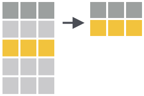

#### greater than

Subset rows where values of `bill_length_mm` are greater than or equal to 50.

```r
penguins %>%
  filter(bill_length_mm >= 50)
```

```
## # A tibble: 57 × 8
##    species island bill_length_mm bill_depth_mm flipper_length_mm body_mass_g
##    <fct>   <fct>           <dbl>         <dbl>             <int>       <int>
##  1 Gentoo  Biscoe           50            16.3               230        5700
##  2 Gentoo  Biscoe           50            15.2               218        5700
##  3 Gentoo  Biscoe           50.2          14.3               218        5700
##  4 Gentoo  Biscoe           50            15.3               220        5550
##  5 Gentoo  Biscoe           59.6          17                 230        6050
##  6 Gentoo  Biscoe           50.5          15.9               222        5550
##  7 Gentoo  Biscoe           50.5          15.9               225        5400
##  8 Gentoo  Biscoe           50.1          15                 225        5000
##  9 Gentoo  Biscoe           50.4          15.3               224        5550
## 10 Gentoo  Biscoe           54.3          15.7               231        5650
## # … with 47 more rows, and 2 more variables: sex <fct>, year <int>
```

#### equal to

Subset rows where values of `island` are equal to ““Biscoe”.

```r
penguins %>%
  filter(island == "Biscoe")
```

```
## # A tibble: 168 × 8
##    species island bill_length_mm bill_depth_mm flipper_length_mm body_mass_g
##    <fct>   <fct>           <dbl>         <dbl>             <int>       <int>
##  1 Adelie  Biscoe           37.8          18.3               174        3400
##  2 Adelie  Biscoe           37.7          18.7               180        3600
##  3 Adelie  Biscoe           35.9          19.2               189        3800
##  4 Adelie  Biscoe           38.2          18.1               185        3950
##  5 Adelie  Biscoe           38.8          17.2               180        3800
##  6 Adelie  Biscoe           35.3          18.9               187        3800
##  7 Adelie  Biscoe           40.6          18.6               183        3550
##  8 Adelie  Biscoe           40.5          17.9               187        3200
##  9 Adelie  Biscoe           37.9          18.6               172        3150
## 10 Adelie  Biscoe           40.5          18.9               180        3950
## # … with 158 more rows, and 2 more variables: sex <fct>, year <int>
```

#### not equal to

Subset rows where values of `sex` are not equal to NA. This filters out the missing values from the `sex` variable.

```r
penguins %>%
  filter(!is.na(sex))
```

```
## # A tibble: 333 × 8
##    species island    bill_length_mm bill_depth_mm flipper_length_mm body_mass_g
##    <fct>   <fct>              <dbl>         <dbl>             <int>       <int>
##  1 Adelie  Torgersen           39.1          18.7               181        3750
##  2 Adelie  Torgersen           39.5          17.4               186        3800
##  3 Adelie  Torgersen           40.3          18                 195        3250
##  4 Adelie  Torgersen           36.7          19.3               193        3450
##  5 Adelie  Torgersen           39.3          20.6               190        3650
##  6 Adelie  Torgersen           38.9          17.8               181        3625
##  7 Adelie  Torgersen           39.2          19.6               195        4675
##  8 Adelie  Torgersen           41.1          17.6               182        3200
##  9 Adelie  Torgersen           38.6          21.2               191        3800
## 10 Adelie  Torgersen           34.6          21.1               198        4400
## # … with 323 more rows, and 2 more variables: sex <fct>, year <int>
```

#### with regex

Subset rows where the values of `island` start with “T”. The function `str_detect()` is from the [stringr](https://stringr.tidyverse.org/) package and looks for values that match a particular string.

```r
penguins %>%
  filter(stringr::str_detect(island, "^T"))
```

```
## # A tibble: 52 × 8
##    species island    bill_length_mm bill_depth_mm flipper_length_mm body_mass_g
##    <fct>   <fct>              <dbl>         <dbl>             <int>       <int>
##  1 Adelie  Torgersen           39.1          18.7               181        3750
##  2 Adelie  Torgersen           39.5          17.4               186        3800
##  3 Adelie  Torgersen           40.3          18                 195        3250
##  4 Adelie  Torgersen           NA            NA                  NA          NA
##  5 Adelie  Torgersen           36.7          19.3               193        3450
##  6 Adelie  Torgersen           39.3          20.6               190        3650
##  7 Adelie  Torgersen           38.9          17.8               181        3625
##  8 Adelie  Torgersen           39.2          19.6               195        4675
##  9 Adelie  Torgersen           34.1          18.1               193        3475
## 10 Adelie  Torgersen           42            20.2               190        4250
## # … with 42 more rows, and 2 more variables: sex <fct>, year <int>
```

#### by multiple conditions

Subset rows where the values of `island` and `year` match specific conditions.

```r
penguins %>%
  filter(island == "Torgersen" & year == 2009)
```

```
## # A tibble: 16 × 8
##    species island    bill_length_mm bill_depth_mm flipper_length_mm body_mass_g
##    <fct>   <fct>              <dbl>         <dbl>             <int>       <int>
##  1 Adelie  Torgersen           38.6          17                 188        2900
##  2 Adelie  Torgersen           37.3          20.5               199        3775
##  3 Adelie  Torgersen           35.7          17                 189        3350
##  4 Adelie  Torgersen           41.1          18.6               189        3325
##  5 Adelie  Torgersen           36.2          17.2               187        3150
##  6 Adelie  Torgersen           37.7          19.8               198        3500
##  7 Adelie  Torgersen           40.2          17                 176        3450
##  8 Adelie  Torgersen           41.4          18.5               202        3875
##  9 Adelie  Torgersen           35.2          15.9               186        3050
## 10 Adelie  Torgersen           40.6          19                 199        4000
## 11 Adelie  Torgersen           38.8          17.6               191        3275
## 12 Adelie  Torgersen           41.5          18.3               195        4300
## 13 Adelie  Torgersen           39            17.1               191        3050
## 14 Adelie  Torgersen           44.1          18                 210        4000
## 15 Adelie  Torgersen           38.5          17.9               190        3325
## 16 Adelie  Torgersen           43.1          19.2               197        3500
## # … with 2 more variables: sex <fct>, year <int>
```

#### by a vector

Subset rows where the values of `species` match those contained in the vector of values, namely “Chinstrap” and “Gentoo”.

```r
penguins %>%
  filter(species %in% c("Chinstrap", "Gentoo"))
```

```
## # A tibble: 192 × 8
##    species island bill_length_mm bill_depth_mm flipper_length_mm body_mass_g
##    <fct>   <fct>           <dbl>         <dbl>             <int>       <int>
##  1 Gentoo  Biscoe           46.1          13.2               211        4500
##  2 Gentoo  Biscoe           50            16.3               230        5700
##  3 Gentoo  Biscoe           48.7          14.1               210        4450
##  4 Gentoo  Biscoe           50            15.2               218        5700
##  5 Gentoo  Biscoe           47.6          14.5               215        5400
##  6 Gentoo  Biscoe           46.5          13.5               210        4550
##  7 Gentoo  Biscoe           45.4          14.6               211        4800
##  8 Gentoo  Biscoe           46.7          15.3               219        5200
##  9 Gentoo  Biscoe           43.3          13.4               209        4400
## 10 Gentoo  Biscoe           46.8          15.4               215        5150
## # … with 182 more rows, and 2 more variables: sex <fct>, year <int>
```

### `slice()`

*Subset rows based on their integer location*

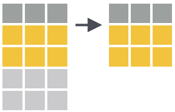

```r
penguins %>%
  slice(1:5)
```

```
## # A tibble: 5 × 8
##   species island bill_length_mm bill_depth_mm flipper_length_… body_mass_g sex
##   <fct>   <fct>           <dbl>         <dbl>            <int>       <int> <fct>
## 1 Adelie  Torge…           39.1          18.7              181        3750 male
## 2 Adelie  Torge…           39.5          17.4              186        3800 fema…
## 3 Adelie  Torge…           40.3          18                195        3250 fema…
## 4 Adelie  Torge…           NA            NA                 NA          NA <NA>
## 5 Adelie  Torge…           36.7          19.3              193        3450 fema…
## # … with 1 more variable: year <int>
```

### `arrange()`

*Change the order of rows in a dataframe*

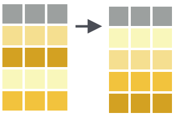

#### ascending order

```r
penguins %>%
  arrange(bill_length_mm)
```

```
## # A tibble: 344 × 8
##    species island    bill_length_mm bill_depth_mm flipper_length_mm body_mass_g
##    <fct>   <fct>              <dbl>         <dbl>             <int>       <int>
##  1 Adelie  Dream               32.1          15.5               188        3050
##  2 Adelie  Dream               33.1          16.1               178        2900
##  3 Adelie  Torgersen           33.5          19                 190        3600
##  4 Adelie  Dream               34            17.1               185        3400
##  5 Adelie  Torgersen           34.1          18.1               193        3475
##  6 Adelie  Torgersen           34.4          18.4               184        3325
##  7 Adelie  Biscoe              34.5          18.1               187        2900
##  8 Adelie  Torgersen           34.6          21.1               198        4400
##  9 Adelie  Torgersen           34.6          17.2               189        3200
## 10 Adelie  Biscoe              35            17.9               190        3450
## # … with 334 more rows, and 2 more variables: sex <fct>, year <int>
```

#### descending order

```r
penguins %>%
  arrange(desc(bill_length_mm))
```

```
## # A tibble: 344 × 8
##    species   island bill_length_mm bill_depth_mm flipper_length_mm body_mass_g
##    <fct>     <fct>           <dbl>         <dbl>             <int>       <int>
##  1 Gentoo    Biscoe           59.6          17                 230        6050
##  2 Chinstrap Dream            58            17.8               181        3700
##  3 Gentoo    Biscoe           55.9          17                 228        5600
##  4 Chinstrap Dream            55.8          19.8               207        4000
##  5 Gentoo    Biscoe           55.1          16                 230        5850
##  6 Gentoo    Biscoe           54.3          15.7               231        5650
##  7 Chinstrap Dream            54.2          20.8               201        4300
##  8 Chinstrap Dream            53.5          19.9               205        4500
##  9 Gentoo    Biscoe           53.4          15.8               219        5500
## 10 Chinstrap Dream            52.8          20                 205        4550
## # … with 334 more rows, and 2 more variables: sex <fct>, year <int>
```

### `count()`

*Count unique values*

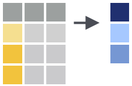

#### by one variable

```r
penguins %>%
  count(island)
```

```
## # A tibble: 3 × 2
##   island        n
##   <fct>     <int>
## 1 Biscoe      168
## 2 Dream       124
## 3 Torgersen    52
```

#### by two variables and sort

```r
penguins %>%
  count(island, sex, sort = TRUE)
```

```
## # A tibble: 9 × 3
##   island    sex        n
##   <fct>     <fct>  <int>
## 1 Biscoe    male      83
## 2 Biscoe    female    80
## 3 Dream     male      62
## 4 Dream     female    61
## 5 Torgersen female    24
## 6 Torgersen male      23
## 7 Biscoe    <NA>       5
## 8 Torgersen <NA>       5
## 9 Dream     <NA>       1
```

### `group_by()` and `summarise()`

*Generate summary statistics by group*

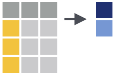

```r
penguins %>%
  group_by(island) %>%
  summarise(mean_body_mass_g = mean(body_mass_g, na.rm = TRUE))
```

```
## # A tibble: 3 × 2
##   island    mean_body_mass_g
##   <fct>                <dbl>
## 1 Biscoe               4716.
## 2 Dream                3713.
## 3 Torgersen            3706.
```

### `across()`

*Apply transformations to multiple variables*

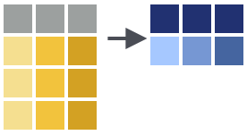

```r
penguins %>%
  group_by(species) %>%
  summarize(across(c(bill_length_mm, body_mass_g), mean, na.rm = TRUE))
```

```
## # A tibble: 3 × 3
##   species   bill_length_mm body_mass_g
##   <fct>              <dbl>       <dbl>
## 1 Adelie              38.8       3701.
## 2 Chinstrap           48.8       3733.
## 3 Gentoo              47.5       5076.
```

**Further resources**

- [‘Data transformation’](https://r4ds.hadley.nz/data-transform.html) in *R for Data Science*, 2nd edition
- [‘Work with Data’](https://rstudio.cloud/learn/primers/2) RStudio primer
- [dplyr cheatsheet](https://github.com/rstudio/cheatsheets/blob/main/data-transformation.pdf)